# 0204_Lec6

Srijan Sengupta

February 4, 2019

Continuing with the theme for this week, we will keep working on exploratory data analysis, or EDA. Recall that the main goal of EDA is to understand the data and bring out its salient characteristics via numerical and visual summaries.

```r
rm(list=ls())
```

# Importing a dataset

Recall that we were working with the NC bike crash data in the last class, and we will continue to work with it. First, load the workspace from last class (download from Canvas if needed)

```r
setwd("G:/My Drive/Teaching/2020S_CMDA3654/Files for Canvas")
load("ncbikeday2.RData")
```

# Data cleaning

Note that there is no R help file to tell us what the variables/features in the dataset mean. We have to figure that out from context.

Further, as we will see, the data might not be nicely structured in a friendly format. We will have to make corrections ourselves.

In the last class, we saw one illustration of this, when we figured out what is wrong with the Biker Age Group feature, and corrected it. Today, we will work through another example of data cleaning.

Let us look at “Crash Day”

```r
levels(data1$CrashDay)
```

```
## [1] ""         "01-01-02" "01-01-03" "01-01-04" "01-01-05" "01-01-06" "01-01-07"
```

```r
table(data1$CrashDay)
```

```
##
##          01-01-02 01-01-03 01-01-04 01-01-05 01-01-06 01-01-07
##      826      873      855      876      917      754      615
```

This clearly looks wrongly coded. Can we figure out what is wrong with this?

Hints:

1. We have seven different values, so this possibly stands for day of week
2. The frequency table gives us hints on what the correct values could be. In particular, note that crash incidents are likely to be less frequent on weekends as traffic is less.
3. We have the actual dates! So we could simply match the day of the week with the actual calendar dates!

For example, we could simply search online for “day of the week for Dec 31 2012”?

By the way, you can also look for day of the week in R. For example,

```r
weekdays(as.Date("2019-02-04"))
```

```
## [1] "Monday"
```

Having figured out what should be the corrected values of the different levels of the categorical feature “CrashDay”, we are now ready to make the correction. Recall how we did this in the last class (for Biker Age group), we simply changed the (character) values of the levels. We can do the same thing here.

```r
levels(data1$CrashDay)[1] = "Monday"
levels(data1$CrashDay)[2] = "Tuesday"
levels(data1$CrashDay)[3] = "Wednesday"
levels(data1$CrashDay)[4] = "Thursday"
levels(data1$CrashDay)[5] = "Friday"
levels(data1$CrashDay)[6] = "Saturday"
levels(data1$CrashDay)[7] = "Sunday"

table(data1$CrashDay) # make sure the intended change has happened
```

```
##
##    Monday   Tuesday Wednesday  Thursday    Friday  Saturday    Sunday
##       826       873       855       876       917       754       615
```

All cleaned up! Note that the lower frequency on weekends makes sense.

## Visualization

```r
library(ggplot2)
library(gcookbook)
library(gridExtra)
```

Let us plot Driver age and biker age.

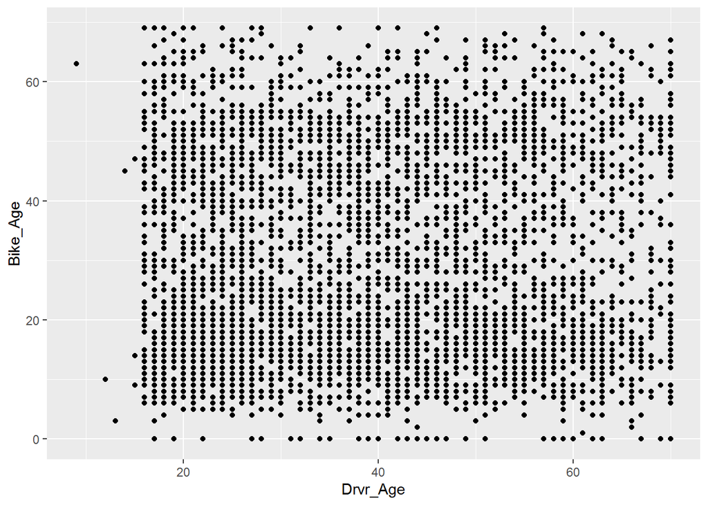

```r
p = ggplot(data1,aes(x=Drvr_Age,y=Bike_Age))
p + geom_point()
```

Recall we can add colors, shapes etc (we added Region to the location plot in the last class).

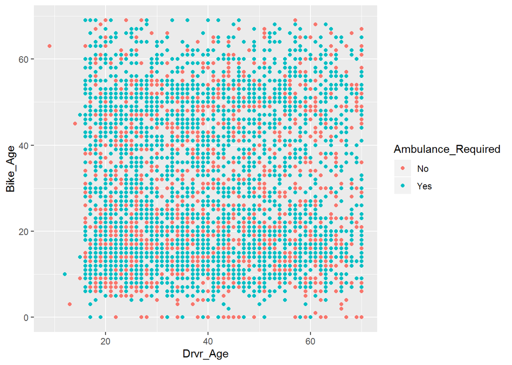

```r
p = ggplot(data1,aes(x=Drvr_Age,y=Bike_Age,color=Ambulance_Required))
p + geom_point() # add AmbulanceR as third variable (color)
```

Do you think there is some obfusctation in the data? Can you guess why?

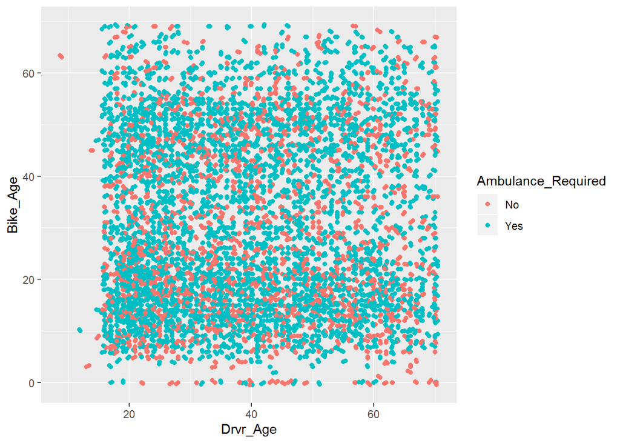

```r
p + geom_point()+geom_jitter(width=0.5,height=0.5) #jitter
```

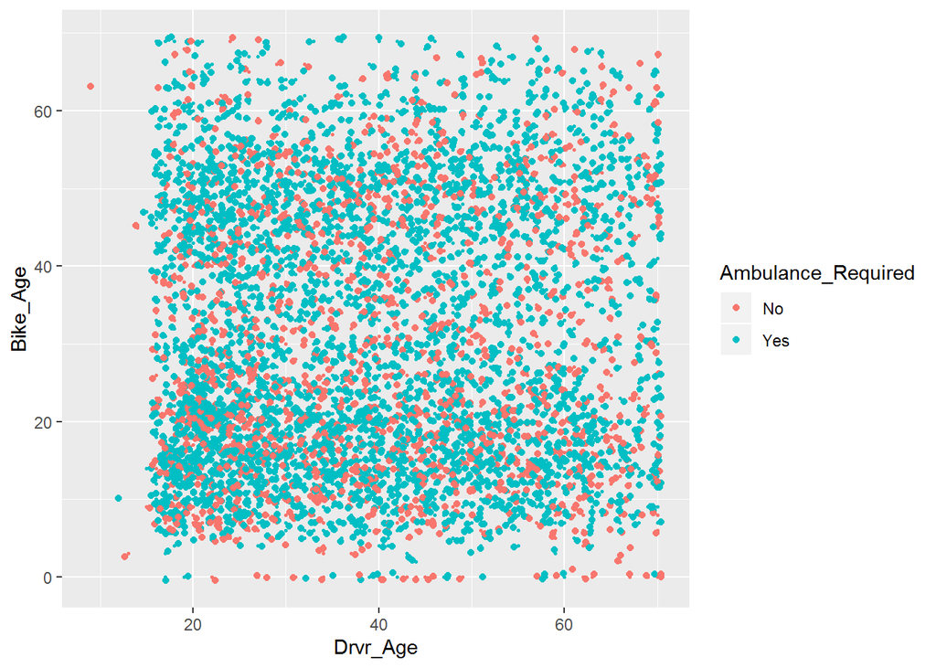

```r
p + geom_point(size=0.5)+geom_jitter(width=0.5,height=0.5) #change size
```

Since there can be several data points with the same x,y, coordinate (same biker and driver age), they get superimposed. Using jitter, we add (small) random shifts that make it easier to tell them apart.

# How to fix the x-y coordinate ratio

```r
?marathon
```

```
## starting httpd help server ... done
```

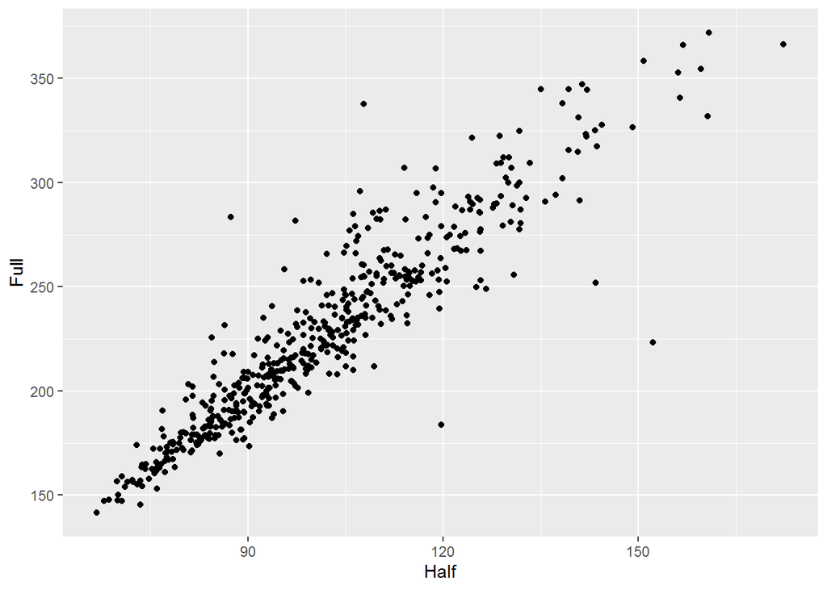

```r
p=ggplot(marathon,aes(x=Half,y=Full))+geom_point()
p
```

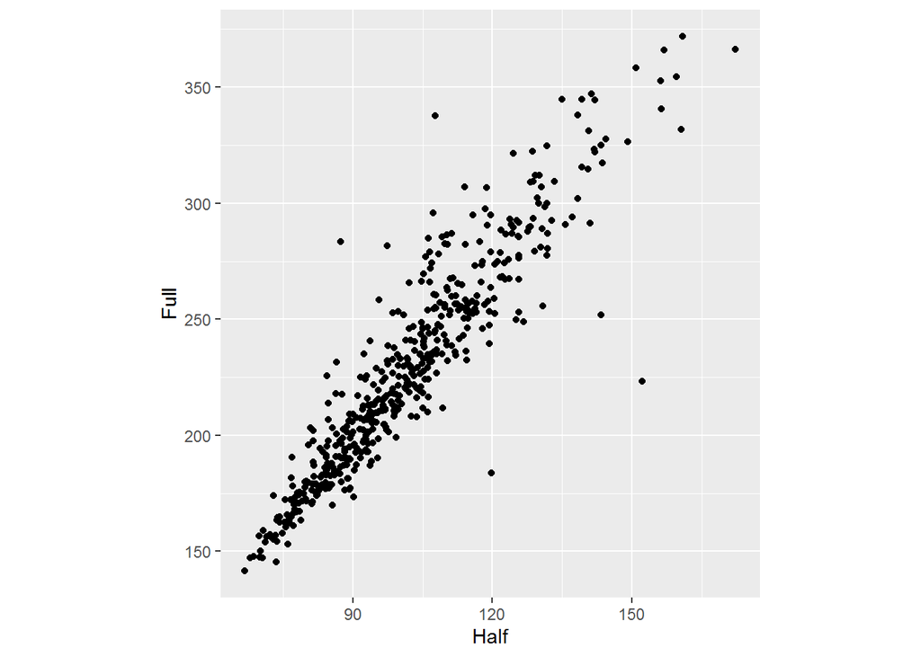

```r
p1 = ggplot(marathon,aes(x=Half,y=Full))+geom_point()+coord_fixed(1/2)
p1
```

# barplots

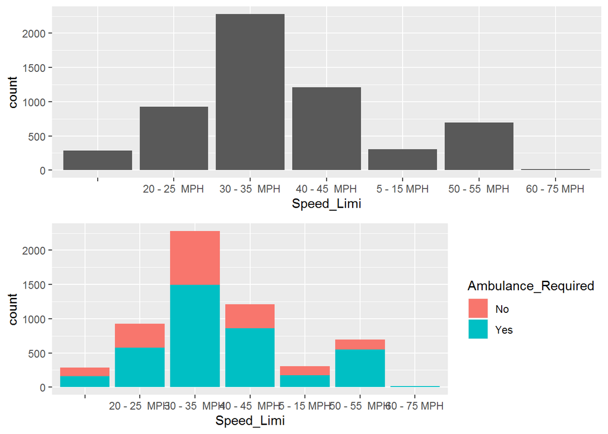

```r
p = ggplot(data1, aes(x=Speed_Limi))
p1=p+geom_bar()
p = ggplot(data1, aes(x=Speed_Limi,fill=Ambulance_Required))
p2=p+geom_bar() # Stacked bar plot
grid.arrange(p1,p2,nrow=2,ncol=1)
```

Can you see the problem? Speed limits are not in order. Let’s change the order of the levels to correct this.

```r
levels(data1$Speed_Limi)
```

```
## [1] ""             "20 - 25  MPH" "30 - 35  MPH" "40 - 45  MPH" "5 - 15 MPH"
## [6] "50 - 55  MPH" "60 - 75 MPH"
```

```r
Speed_Limit = factor(data1$Speed_Limi,
                     levels(data1$Speed_Limi)[c(5,2,3,4,6,7,1)])
data1 = cbind(data1,Speed_Limit)
```

Now let us construc the plots again

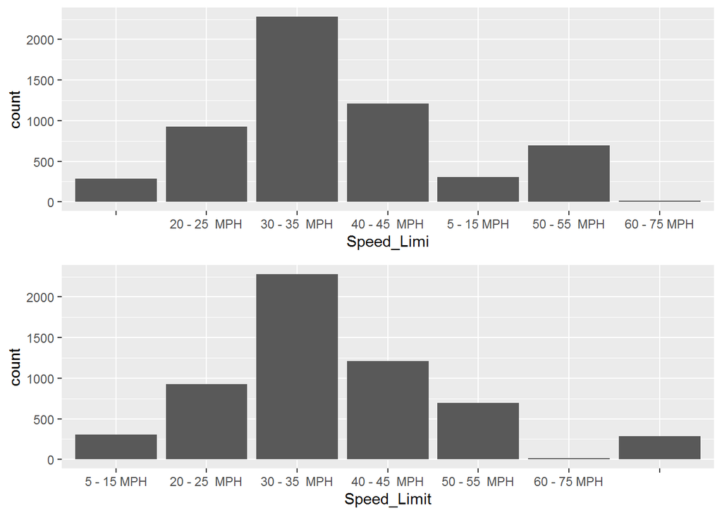

```r
p1 = ggplot(data1, aes(x=Speed_Limi)) + geom_bar()
p2 = ggplot(data1, aes(x=Speed_Limit)) + geom_bar() # in the second plot, speed limits are now in order
grid.arrange(p1,p2,nrow=2,ncol=1)
```

Let’s add color according to Ambulance requirement.

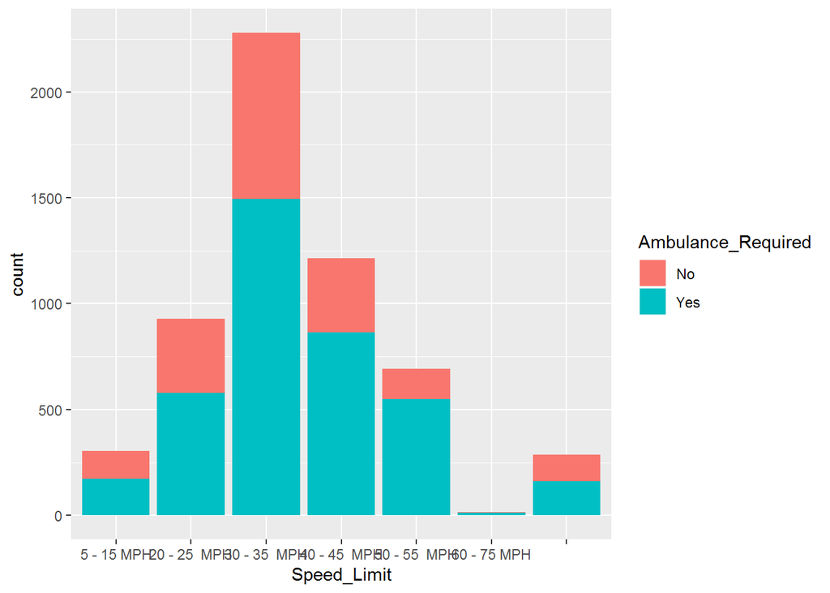

```r
ggplot(data1, aes(x=Speed_Limit,fill=Ambulance_Required))+ geom_bar()
```

# Area graphs and stacked area graphs

```r
data_pop = uspopage
?uspopage
```

First, let us calculate the total population in each year.

```r
yrs = unique(data_pop$Year) # array of years
tot = rep(NA,length(yrs))     # empty array for total population every year
for (i in 1:length(yrs)){
  foo = subset(data_pop, Year == yrs[i]) # subset of data for specific year
  tot[i] = sum(foo$Thousands) #total population for specific year
}
data_poptot = data.frame(yrs,tot)     # combine year and total population
```

Now we have the data for total population. Let us construct the area graph.

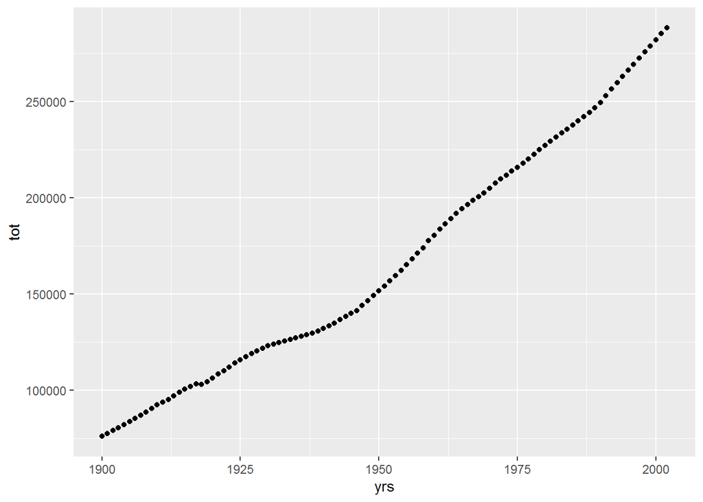

```r
p = ggplot(data_poptot,aes(x=yrs,y=tot))
p + geom_point()              # scatterplot
```

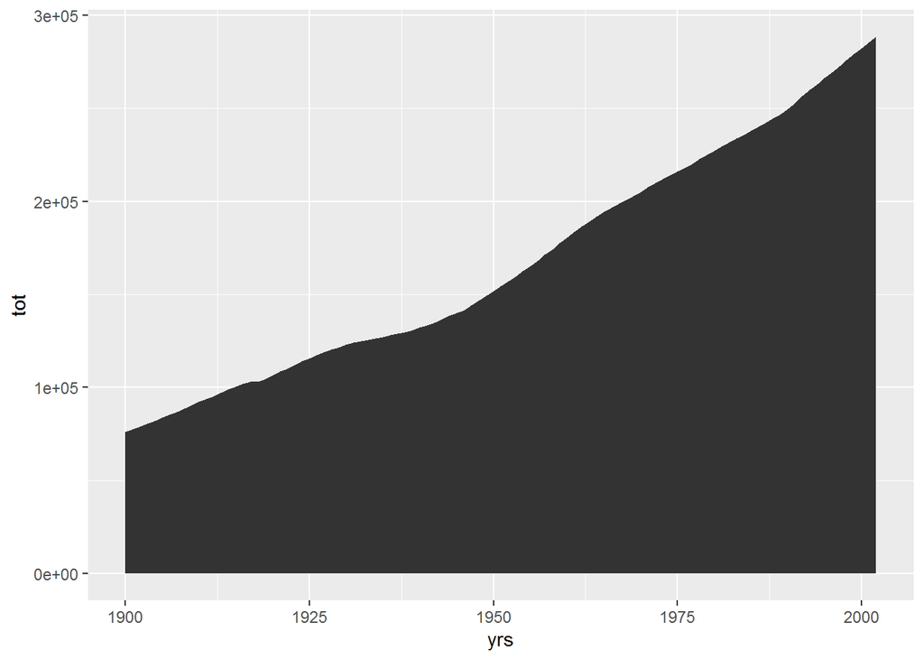

```r
p + geom_area()               # area graph
```

We can also construct a stacked area graph.

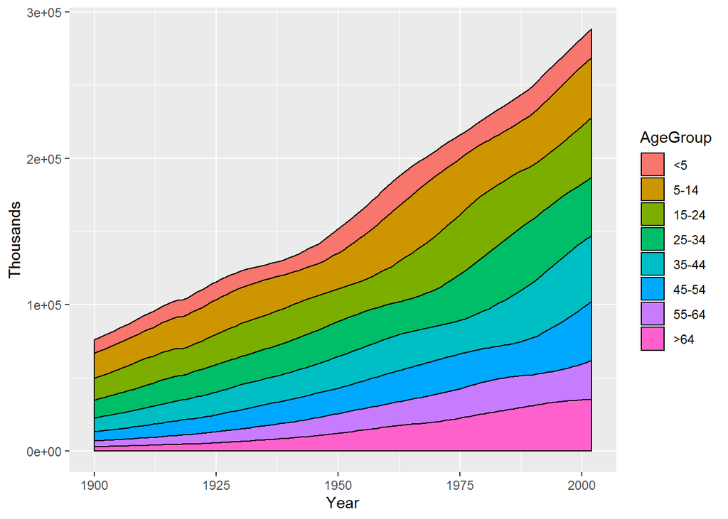

```r
p = ggplot(data_pop, aes(x=Year,y=Thousands,fill=AgeGroup))
p +  geom_area(colour="black") #stacked area graph
```

Suppose we want to reverse the stacking order of age groups

```r
data_pop1 = data_pop #make new copy
data_pop1$AgeGroup = factor(data_pop$AgeGroup,
                        levels = rev(levels(data_pop$AgeGroup)))
```

we keep the variables values unchanged, but reverse the ordering of the factor levels. This is reminiscent of what we did with Speed Limit in lines 16-17, where we changed the ordering of factor levels for speed limit.

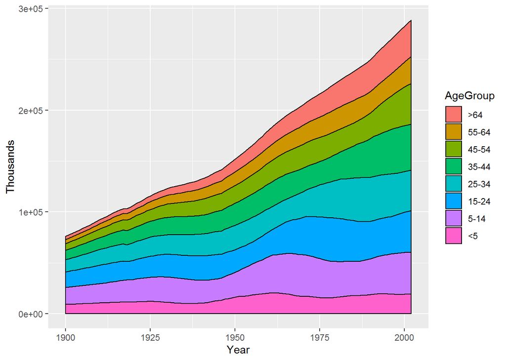

```r
ggplot(data_pop1,aes(x=Year,y=Thousands,fill=AgeGroup))+
  geom_area(colour="black")
```

Note the baby boomer bump (1950-1965) moving up.